# Data wrangling

Hunter Riccardelli

Oregon State University

24 April 2026

## Goal and requirements

The goal of this assignment is to impress with your data wrangling skills.

Some additional points:

- You can create a new GitHub repo for this assignment.
- Name your GitHub repo something like `aec699-hw2-datawrangling-lastname`.
- Make sure to organize your data into a `data/` folder and your code into a `scripts/` or `code/` folder.
- Do not forget to knit the assignment (click the “Knit” button, or press `Ctrl+Shift+K`) before submitting.
- **Please put your (written) answers in bold.**

### What you will be graded on

- Is the code correct?
- Are the outcomes correct?
- Did you show your work?
- Are the figures clear?
- Did you follow the instructions of the assignment?

## Preliminaries:

### Load libraries

It is a good idea to load your libraries at the top of the Rmd document so that everyone can see what you are using. Similarly, it is good practice to set this type of chunk with `cache=FALSE` to ensure that the libraries are dynamically loaded each time you knit the document.

*Hint: I have only added the libraries needed to download and read the data. You will need to load additional libraries to complete this assignment. Add them here once you discover that you need them.*

```r
if (!require("pacman")) install.packages("pacman")  # install the pacman package if necessary
```

```r
pacman::p_load(httr, readxl, here, tidyverse, janitor, lubridate, plotly)  # install other packages using pacman::p_load()
```

### Read in the data

Use `httr::GET()` to fetch the EIA excel file for us from web.

```r
# library(here)  # already loaded
# library(httr)  # already loaded
url <- "https://www.eia.gov/coal/archive/coal_historical_exports.xlsx"
if(!file.exists(here::here("data/coal.xlsx"))) {  # only download the file if we need to
  GET(url, write_disk(here::here("data/coal.xlsx")))  # modify relative path to match directory
}
```

```
## Response [https://www.eia.gov/coal/archive/coal_historical_exports.xlsx]
##   Date: 2026-04-17 22:46
##   Status: 200
##   Content-Type: application/vnd.openxmlformats-officedocument.spreadsheetml.sheet
##   Size: 997 kB
## <ON DISK>  C:\Users\hunte\OneDrive - Oregon State University\Grad Year 3\Data Science\osu-aec699-s26\data\coal.xlsx
```

Next, we read in the file.

```r
# library(readxl) already loaded
coal <- read_xlsx(here::here("data/coal.xlsx"), skip=3, na=".")
```

We are now ready to go.

## 1) Clean the column names

The column (i.e. variable) names are not great: Spacing, uppercase letters, etc. Clean them.

```r
coal_clean <- coal %>%
  janitor::clean_names()
colnames(coal_clean)
```

```
##  [1] "year"                     "quarter"
##  [3] "type"                     "customs_district"
##  [5] "coal_origin_country"      "coal_destination_country"
##  [7] "steam_coal"               "steam_revenue"
##  [9] "metallurgical"            "metallurgical_revenue"
## [11] "total"                    "total_revenue"
## [13] "coke"                     "coke_revenue"
```

*Hint: You can use `gsub()` and regular expressions, or external packages like `magrittr` or `janitor`.*

## 2) Total US coal exports over time (year only)

Plot the US’s total coal exports over time by year ONLY. What secular trends do you notice in the data?

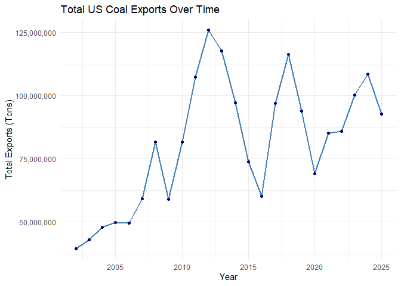

```r
coal_clean %>%
  group_by(year) %>%
  summarize(total = sum(total, na.rm = TRUE)) %>%
  ggplot(aes(x = year, y = total)) +
  geom_line(color = "steelblue", linewidth = 1) +
  geom_point(color = "navy") +
  scale_y_continuous(labels = scales::comma) +
  labs(title = "Total US Coal Exports Over Time",
       x = "Year",
       y = "Total Exports (Tons)") +
  theme_minimal()
```

## 3) Total US coal exports over time (year AND quarter)

Now do the same as the above, except aggregated quarter of year (2001Q1, 2002Q2, etc.). Do you notice any seasonality that was masked from the yearly totals?

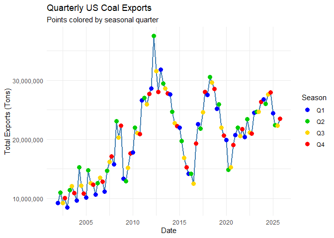

```r
coal_ts <- coal_clean %>%
  mutate(date = yq(paste(year, quarter, sep = "Q"))) %>%
  group_by(date) %>%
  summarize(total = sum(total, na.rm = TRUE))%>%
  mutate(qtr = factor(quarter(date)))

ggplot(coal_ts, aes(x = date, y = total)) +
  geom_line(color = "steelblue", linewidth = 1) +
  geom_point(aes(color = qtr), size = 3) +
  scale_color_manual(
    values = c("1" = "blue", "2" = "green3", "3" = "gold", "4" = "red"),
    labels = c("Q1", "Q2", "Q3", "Q4"),
    name = "Season"
  ) +
  scale_y_continuous(labels = scales::comma) +
  labs(
    title = "Quarterly US Coal Exports",
    subtitle = "Points colored by seasonal quarter",
    x = "Date",
    y = "Total Exports (Tons)"
  ) +
  theme_minimal()
```

**When dissaggregating from annual exports we see that coal exports are even more volatile and follow periods of export declines roughly corresponding to the winter.** *Hint: ggplot2 is going to want you to convert your quarterly data into actual date format before it plots nicely. (i.e. Don’t leave it as a string.)*

## 4) Exports by destination country

### 4.1) Create a new data frame

```r
coal_country <- coal_clean %>%
  mutate(date = yq(paste(year, quarter, sep = "Q"))) %>%
  group_by(coal_destination_country, year, quarter, date) %>%
  summarize(total_exports = sum(total, na.rm = TRUE), .groups = "drop")

print(coal_country)
```

```
## # A tibble: 5,750 × 5
##    coal_destination_country  year quarter date       total_exports
##    <chr>                    <dbl>   <dbl> <date>             <dbl>
##  1 Albania                   2016       4 2016-10-01            74
##  2 Albania                   2023       2 2023-04-01         24152
##  3 Algeria                   2002       1 2002-01-01        129305
##  4 Algeria                   2002       3 2002-07-01         62931
##  5 Algeria                   2002       4 2002-10-01        129563
##  6 Algeria                   2003       1 2003-01-01        128525
##  7 Algeria                   2003       2 2003-04-01         70539
##  8 Algeria                   2003       3 2003-07-01        141813
##  9 Algeria                   2003       4 2003-10-01         66499
## 10 Algeria                   2004       1 2004-01-01        141438
## # ℹ 5,740 more rows
```

Create a new data frame called `coal_country` that aggregates total exports by destination country (and quarter of year). Make sure you print the resulting data frame so that it appears in the knitted R markdown document.

### 4.2) Inspect the data frame

It looks like some countries are missing data for a number of years and periods (e.g. Albania). Confirm that this is the case. What do you think is happening here?

**This is true, we see multiple countries with missing data. This may be the result of measurement error, export restrictions or simply not exporting coal to those countries, leading to missing observations across time.**

### 4.3) Complete the data frame

Fill in the implicit missing values, so that each country has a representative row for every year-quarter time period. In other words, you should modify the data frame so that every destination country has row entries for all possible year-quarter combinations (from 2002Q1 through the most recent quarter). I.e., a balanced panel. Order your updated data frame by country, year and, quarter.

**Assuming these values are true 0’s, another alternative would be filling in linear values between observations.**

```r
coal_country_complete <- coal_country %>%
  complete(coal_destination_country, nesting(year, quarter, date), fill = list(total_exports = 0)) %>%
  arrange(coal_destination_country, year, quarter)

print(coal_country_complete)
```

```
## # A tibble: 14,592 × 5
##    coal_destination_country  year quarter date       total_exports
##    <chr>                    <dbl>   <dbl> <date>             <dbl>
##  1 Albania                   2002       1 2002-01-01             0
##  2 Albania                   2002       2 2002-04-01             0
##  3 Albania                   2002       3 2002-07-01             0
##  4 Albania                   2002       4 2002-10-01             0
##  5 Albania                   2003       1 2003-01-01             0
##  6 Albania                   2003       2 2003-04-01             0
##  7 Albania                   2003       3 2003-07-01             0
##  8 Albania                   2003       4 2003-10-01             0
##  9 Albania                   2004       1 2004-01-01             0
## 10 Albania                   2004       2 2004-04-01             0
## # ℹ 14,582 more rows
```

*Hints: See `?tidyr::complete()` for some convenient options. Another option is `tidyr::crossing()`. Do not forget to print `coal_country` after you have updated the data frame to show the results.*

### 4.4 Some more tidying up

In answering the previous question, you *may* encounter a situation where the data frame contains a quarter that is missing total export numbers for *all* countries. Did this happen to you? Filter out the completely missing quarter if so. Also: Why do you think this might have happened? (Please answer the latter question even if it did not happen to you.)

```r
missing_inspection <- coal_country %>%
  complete(coal_destination_country, nesting(year, quarter, date)) %>%
  group_by(date) %>%
  summarize(
    total_countries = n(),
    missing_values = sum(is.na(total_exports))
  ) %>%
  filter(missing_values > 0) %>%
  arrange(desc(missing_values))

print(missing_inspection)
```

```
## # A tibble: 96 × 3
##    date       total_countries missing_values
##    <date>               <int>          <int>
##  1 2003-10-01             152            110
##  2 2002-01-01             152            106
##  3 2002-10-01             152            106
##  4 2002-07-01             152            105
##  5 2003-01-01             152            105
##  6 2003-04-01             152            103
##  7 2003-07-01             152            103
##  8 2004-04-01             152            103
##  9 2024-10-01             152            103
## 10 2025-10-01             152            103
## # ℹ 86 more rows
```

**The printout shows that at the highest missing frequency, we still have some observations for countries. If this did happen it may be the result of a data reporting error, trade restrictions or global shocks to coal sector**

```r
coal_country_complete <- coal_country_complete %>%
  group_by(date) %>%
  filter(sum(total_exports) > 0) %>%
  ungroup()
```

### 4.5) Culmulative top 10 US coal export destinations

Produce a vector – call it `coal10_culm` – of the top 10 top coal destinations over the full study period. What are they?

```r
coal10_cumul <- coal_country_complete %>%
  group_by(coal_destination_country) %>%
  summarize(grand_total = sum(total_exports)) %>%
  slice_max(order_by = grand_total, n = 10) %>%
  pull(coal_destination_country)
```

**The top coal receiving nations are:**

```r
print(coal10_cumul)
```

```
##  [1] "Canada"                          "India"
##  [3] "Netherlands"                     "Brazil"
##  [5] "Japan"                           "South Korea (Republic of Korea)"
##  [7] "United Kingdom"                  "China"
##  [9] "Italy"                           "Germany, Federal Republic of"
```

### 4.6) Recent top 10 US coal export destinations

Now do the same, except for the most recent period on record (i.e. final quarter in the dataset). Call this vector `coal10_recent` and make sure to print it so that it is visible too. Are there any interesting differences between the two vectors? Apart from any secular trends, what else might explain these differences?

```r
recent_date <- max(coal_country_complete$date)

coal10_recent <- coal_country_complete %>%
  filter(date == recent_date) %>%
  group_by(coal_destination_country) %>%
  summarize(recent_total = sum(total_exports)) %>%
  slice_max(order_by = recent_total, n = 10) %>%
  pull(coal_destination_country)

print(coal10_recent)
```

```
##  [1] "India"                           "Netherlands"
##  [3] "Canada"                          "Brazil"
##  [5] "Japan"                           "Indonesia"
##  [7] "Turkey"                          "South Korea (Republic of Korea)"
##  [9] "Morocco"                         "Germany, Federal Republic of"
```

**Interestingly, we find significant discrepancies between the two groups. In the most recent data we see that Canada has been superseded by India and the Netherlands. Indonesia, Turkey and Morocco have also imported more coal and replaced European trade partners. Finally, China has dropped out of the top 10. This is likely driven by climate goals in the EU with trade restrictions towards China.**

### 4.7) US coal exports over time by country

Plot the quarterly coal exports over time, but now disaggregated by country. In particular, highlight the top 10 (cumulative) export destinations and then sum the remaining countries into a combined “Other” category. (In other words, your figure should contain the time series of eleven different countries/categories.)

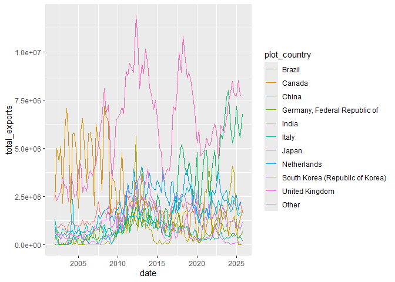

```r
coal_plot_data <- coal_country_complete %>%
  mutate(plot_country = if_else(coal_destination_country %in% coal10_cumul,
                                coal_destination_country, "Other")) %>%
  group_by(date, plot_country) %>%
  summarize(total_exports = sum(total_exports), .groups = "drop") %>%
  mutate(plot_country = fct_relevel(as.factor(plot_country), "Other", after = Inf))

ggplot(coal_plot_data, aes(x = date, y = total_exports, color = plot_country)) +
  geom_line()
```

### 4.8) Make it pretty

Take your previous plot and add some style to it. That is, try to make it as visually appealing as possible without overloading it with chart junk.

*Hint: You have a lot of options here. If you have not already done so, consider a more bespoke theme with the `ggthemes` or `cowplot` packages. Try out `scale_fill_brewer()` and `scale_color_brewer()` for a range of interesting color palettes. Try transparency effects with `alpha`. Give your axis labels more refined names with the `labs()` layer in ggplot2. Or, you might want to scale (i.e. normalize) your y-variable to get rid of all those zeros. You can shorten any country names to their ISO abbreviation; see `?countrycode::countrycode`. More substantively, but more complicated, you might want to re-order your legend (and the plot itself) according to the relative importance of the destination countries. See `?forcats::fct_reorder` or `?forcats::fct_relevel`.*

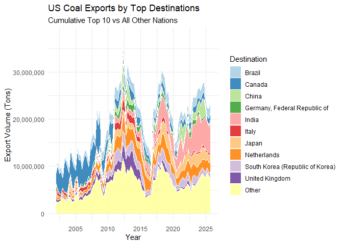

```r
p <- ggplot(coal_plot_data, aes(x = date, y = total_exports, fill = plot_country)) +
  geom_area(alpha = 0.85, color = "white", linewidth = 0.1) +
  scale_fill_brewer(palette = "Paired") +
  scale_y_continuous(labels = scales::comma) +
  labs(title = "US Coal Exports by Top Destinations",
       subtitle = "Cumulative Top 10 vs All Other Nations",
       x = "Year",
       y = "Export Volume (Tons)",
       fill = "Destination") +
  theme_minimal() +
  theme(legend.position = "right")

p
```

### 4.9) Make it interactive

Create an interactive version of your previous figure.

```r
ggplotly(p)
```

[interactive chart not shown]

*Hint: Take a look at plotly::ggplotly(), or the gganimate package.*

## 5) Show something interesting

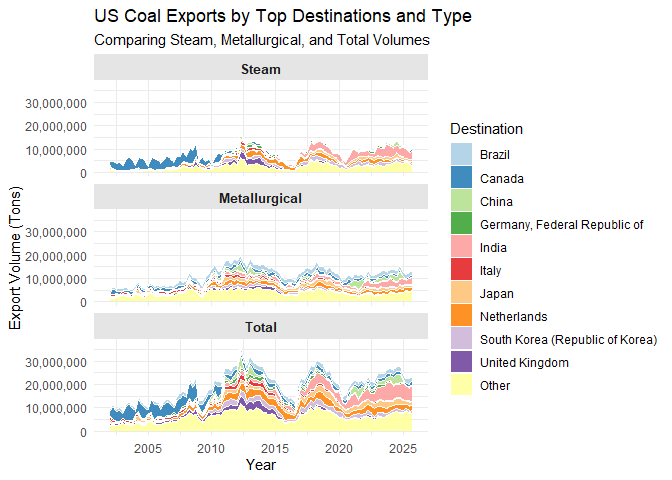

```r
coal_plot_data_multi <- coal_clean %>%
  mutate(date = yq(paste(year, quarter, sep = "Q"))) %>%
  mutate(plot_country = if_else(coal_destination_country %in% coal10_cumul,
                                coal_destination_country, "Other")) %>%
  group_by(date, plot_country) %>%
  summarize(
    Steam = sum(steam_coal, na.rm = TRUE),
    Metallurgical = sum(metallurgical, na.rm = TRUE),
    Total = sum(total, na.rm = TRUE),
    .groups = "drop"
  ) %>%
  pivot_longer(
    cols = c(Steam, Metallurgical, Total),
    names_to = "coal_type",
    values_to = "volume"
  ) %>%
  mutate(
    plot_country = fct_relevel(as.factor(plot_country), "Other", after = Inf),
    coal_type = fct_relevel(as.factor(coal_type), "Steam", "Metallurgical", "Total")
  )

z <- ggplot(coal_plot_data_multi, aes(x = date, y = volume, fill = plot_country)) +
  geom_area(alpha = 0.85, color = "white", linewidth = 0.1) +
  facet_wrap(~ coal_type, ncol = 1) +
  scale_fill_brewer(palette = "Paired") +
  scale_y_continuous(labels = scales::comma) +
  labs(title = "US Coal Exports by Top Destinations and Type",
       subtitle = "Comparing Steam, Metallurgical, and Total Volumes",
       x = "Year",
       y = "Export Volume (Tons)",
       fill = "Destination") +
  theme_minimal() +
  theme(
    legend.position = "right",
    # Add styling to the facet labels to make them pop
    strip.background = element_rect(fill = "gray90", color = NA),
    strip.text = element_text(face = "bold", size = 10)
  )

z
```

```r
ggplotly(z)
```

[interactive chart not shown]

**The final interactive graph shows the top coal receiving countries by type (steam generating, steel producing) and total. We find that early 2000s coal exports were driven largely by Canadian energy production (likely replaced by Canadian domestic fossil fuels) with later growth driven by Indian imports of coal for energy production.**

There is still a lot to explore with this dataset. Your final task is to show something interesting about the data. Drill down into the data and explain what is driving the secular trends that we have observed above. Or highlight interesting seasonality within a particular country. Or go back to the original `coal` data frame and look at exports by customs district, or by coal type. Do we have changes or trends there? Etcetera. The only requirement is that you show your work and explain what you have found.